# titanic_survival_exploration

# Objective: Attain an accuracy of 80%.

Pclass, Sex, Age, SibSp, and Parch are some suggested features to try.

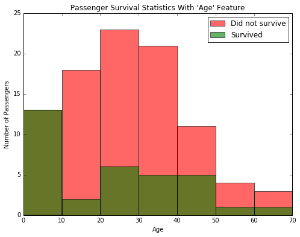

```python
vs.survival_stats(data, outcomes, 'Age', ["Sex == 'male'", "SibSp > 0"])
```

#### Decision: no improvement

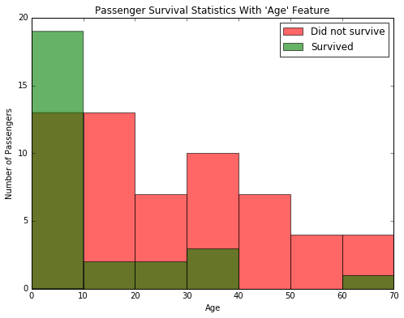

```python
vs.survival_stats(data, outcomes, 'Age', ["Sex == 'male'", "Parch > 0"])
```

#### Decision: no improvement

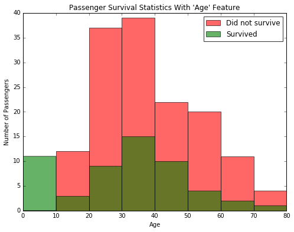

```python
vs.survival_stats(data, outcomes, 'Age', ["Sex == 'male'", "Pclass < 3"])
```

```python
def predictions_3(data):
    """ Model with three features:
            - Predict a passenger survived if they are female.
            - Predict a passenger survived if they are male,
                under 10 years old, AND in first or second class."""

    predictions = []
    for _, passenger in data.iterrows():

        if passenger['Sex']=='male':

            if passenger['Age']<=10 and passenger['Pclass']<3:

                predictions.append(1)

            else:

                predictions.append(0)

        elif passenger['Sex']=='female':

            predictions.append(1)

        else:

            return "ERROR: non-binary value found in Titanic passenger sex"

    # Return our predictions
    return pd.Series(predictions)

# Make the predictions
predictions = predictions_3(data)
```

```python
accuracy_score(outcomes, predictions)
```

```
'Predictions have an accuracy of 79.91%.'
```

#### Almost!

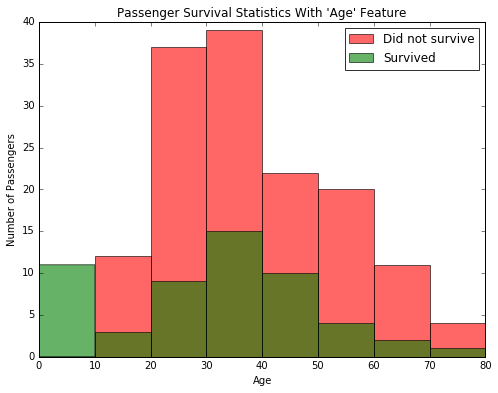

```python
vs.survival_stats(data, outcomes, 'Age', ["Sex == 'male'", "Pclass < 3"])
```

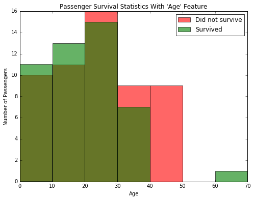

```python
vs.survival_stats(data, outcomes, 'Age', ["Sex == 'female'", "Pclass == 3"])
```

```python
def predictions_3(data):
    """ Model with three features:
            Predict a passenger survived if they are in first or second class, AND:
                - female, and under 20 or over 60 years old.
                - male, and under 10 years old."""

    predictions = []
    for _, passenger in data.iterrows():

        if passenger['Sex']=='male':
            if passenger['Pclass']<3 and passenger['Age']<10:
                predictions.append(1)
            else:
                predictions.append(0)

        elif passenger['Sex']=='female':
            if passenger['Pclass']==3 and 20<passenger['Age']<60:
                predictions.append(0)
            else:
                predictions.append(1)
        else:
            return "ERROR: non-binary value found in Titanic passenger sex"

    # Return our predictions
    return pd.Series(predictions)

# Make the predictions
predictions = predictions_3(data)
```

```python
accuracy_score(outcomes, predictions)
```

```
'Predictions have an accuracy of 81.03%.'
```

### successfully met objective

The first exploration I made was into whether having a sibling or spouse had any bearing on survival. By plotting a visual, this seemed to have no positive contribution.

Next was the effect of whether a passenger had a parent or child, and this plotted effect seemed relatively negligible as well.

## Question 5

Think of a real-world scenario where supervised learning could be applied. What would be the outcome variable that you are trying to predict? Name two features about the data used in this scenario that might be helpful for making the predictions.

Supervised learning can be applied to commercial airfare to predict a ticket price given basic features such as airport cities, day of year, and time of day; in addition to airline company, meteorological forecasts, crude oil price forecasts, and more.